# Phylogenetics: Species Delimitation

Speciation Genomics · PB 495/595 Plant Evolutionary Biology

George P. Tiley

8 October 2026

# Continuing Phylogenetics

## Summary

- We can estimate phylogenetic trees from DNA sequence data using models of sequence evolution.
- Model-based phylogenies have likelihoods.
- Likelihoods can be used to test multiple competing hypotheses.

## Learning objectives

- Understand biological sources of discordance between gene trees and species trees.
- Recognize cytonuclear discordance in plant phylogenetics.
- Be familiar with some species delimitation techniques.
- Apply the basic test of historical introgression (D-statistic / ABBA-BABA) between species.

# Gene trees within species trees

## Gene trees and species trees

Each locus has its **own** genealogy; these **gene trees** can be different from the **species tree**.

Three biological sources of gene tree discordance:

1. Incomplete lineage sorting (ILS) - example: rapid speciation in Andean tomato relatives Pease et al. (2016)
2. Gene duplication and loss - example: polyploidy leads to different trees due to differential homeolog retention Jiao et al. (2011)
3. Hybridization / introgression - example: hybrid sunflower species in extreme habitats Rieseberg et al. (2003)

## Cytonuclear discordance

## Cytonuclear discordance is common in plants

Chloroplasts can move between species through hybridization. Sometimes there is little evidence of the historical gene flow on the nuclear genome, but the chloroplast remains *captured*.

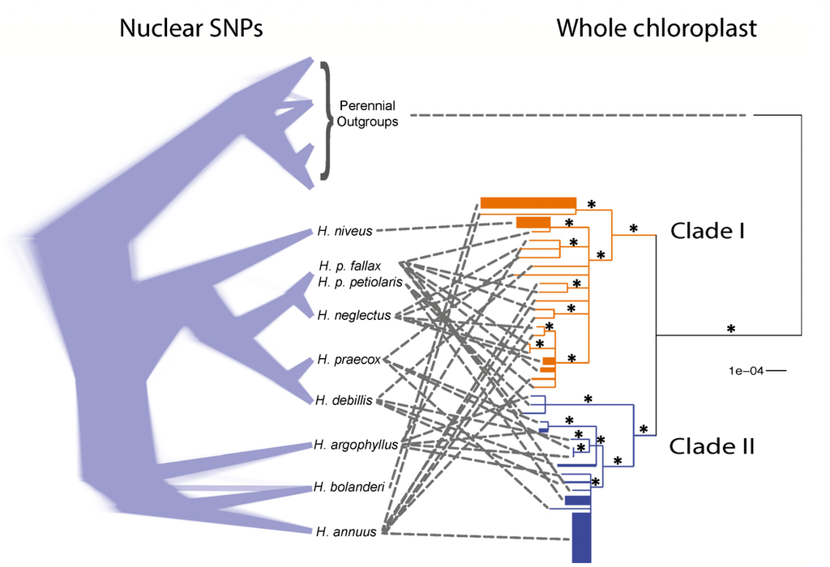

Chloroplast capture among annual sunflowers (*Helianthus*). Fig. 2 from Lee-Yaw et al. (2019)

## When concatenated ML fails

The *anomaly zone* was given by Degnan and Rosenberg (2006) as:

$$y < a(x) = \log\!\left[\frac23 + \frac{3e^{2x}-2}{18\,(e^{3x}-e^{2x})}\right]$$

For example, at $x=y=0.1$: $P[(((A,B),C),D)] = 0.10$, but $P[((A,B),(C,D))] = 0.13$.

## When concatenated ML fails

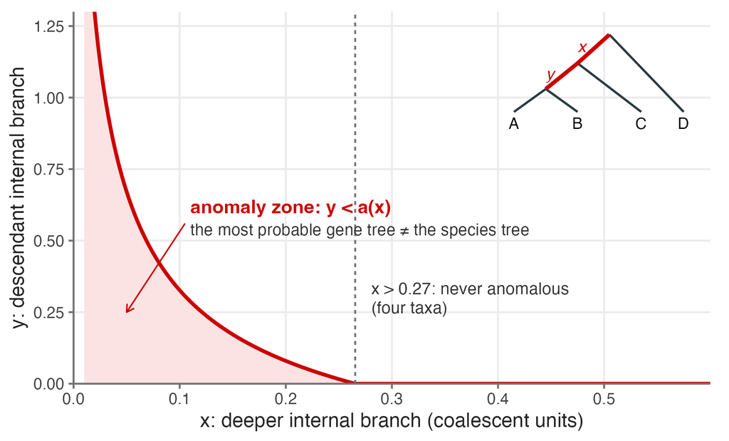

The anomaly zone boundary a(x) plotted against x. Based on analytical results from Degnan and Rosenberg (2006).

# The multispecies coalescent

## The coalescent for a single population

$$P(\text{Two sequences do not coalesce in i generations}) \approx 1 - e^{-\frac{-i}{2N}} \approx e^{-T}$$

$T$ is our **coalescent unit** and $T = \frac{\text{# of generations}}{2N}$.

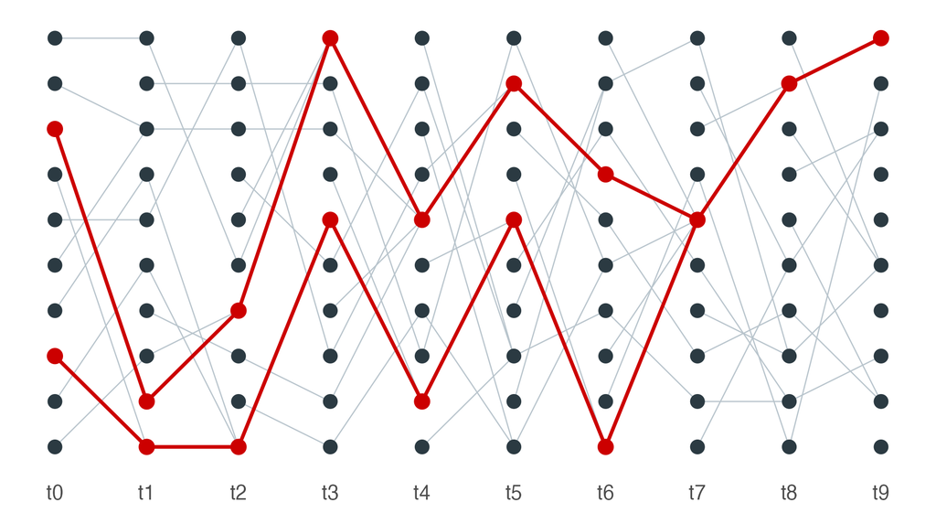

A Wright-Fisher process for 10 individuals.

## Deep coalescence

ILS: How much discordance does the coalescent predict?

For a rooted triple with internal branch length $T$, the probability that a gene tree matches the species tree is

$$P(\text{gene tree matches species tree}) = 1 - \tfrac{2}{3} e^{-T}$$

and each of the two discordant gene trees occur with probability

$$P(\text{gene tree is discordant}) = \frac{1}{3} e^{-T}$$

The coalescent predicts that the discordant gene trees are **equally probable** Hudson (1983).

## Deep coalescence

ILS is reduced as the internal branch length $T$ increases.

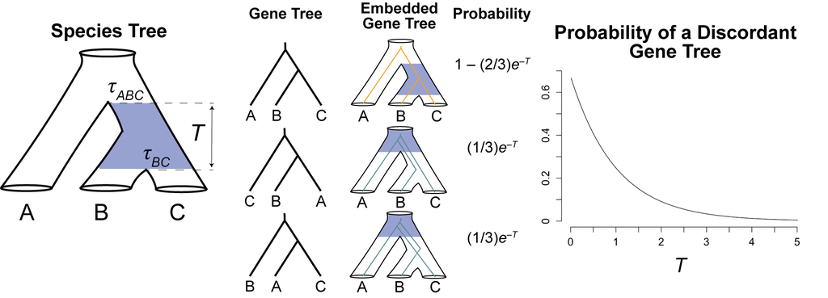

Predictions of gene tree discordance. Fig 2. of Tiley et al. (2020)

# Testing for introgression: D-statistics

## Four taxa, three site patterns

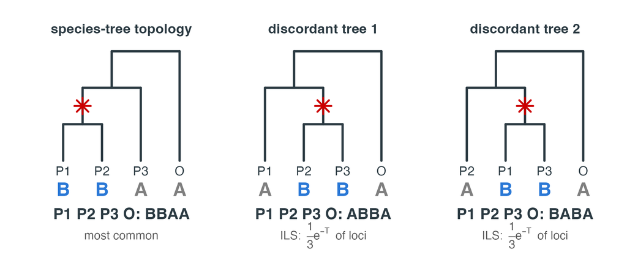

- Take the species tree $(((P1,P2),P3),O)$. The outgroup carries the **ancestral** allele (A); a mutation on an internal branch makes the tips below it **derived** (B) (Green et al. 2010).
- **BBAA** comes from the matching gene tree. **ABBA** and **BABA** need a discordant one.
- Under ILS the two discordant trees are equally likely, so ABBA and BABA SNPs should be **equally** common — the same symmetry as the three gene-tree probabilities.

## Patterson’s $D$

$$D = \frac{n_{\text{ABBA}} - n_{\text{BABA}}}{n_{\text{ABBA}} + n_{\text{BABA}}}$$

- $D = 0$: ILS alone. $D>0$: excess **ABBA**, so P3 shares alleles with P2. $D<0$: excess **BABA**, so P3 shares alleles with P1 (Green et al. 2010; Durand et al. 2011).
- Needs a **biallelic SNP** at every site, with one allele per taxon (or a frequency per population); sites with any other pattern (BBAA, AABA, …) are ignored.
- Assumes the outgroup gives the ancestral state and the same substitution rate in P1 and P2.
- A **test of the null** (no gene flow), not an estimate of how much gene flow.

## Worked example: counting patterns

| Site | P1 | P2 | P3 | O | Pattern |
| --- | --- | --- | --- | --- | --- |
| 1 | G | T | T | G | **ABBA** |
| 2 | T | G | T | G | **BABA** |
| 3 | C | T | T | C | **ABBA** |
| 4 | A | A | G | A | AABA |
| 5 | T | T | A | A | BBAA |
| 6 | A | C | C | A | **ABBA** |
| 7 | G | A | G | A | **BABA** |
| 8 | C | T | C | C | ABAA |
| 9 | T | T | T | C | BBBA |
| 10 | A | G | G | A | **ABBA** |

1. Call each base **A** if it matches the outgroup, **B** if not.
2. Keep only ABBA and BABA sites.
3. Count: $n_{\text{ABBA}} = 4$, $n_{\text{BABA}} = 2$.

$$D = \frac{4 - 2}{4 + 2} = 0.33$$

Six informative sites are far too few to trust. The real analysis uses the whole genome.

## Worked example: genome-wide $D$

Suppose a whole-genome SNP set gives $n_{\text{ABBA}} = 1{,}250$ and $n_{\text{BABA}} = 1{,}000$:

$$D = \frac{1250 - 1000}{1250 + 1000} = \frac{250}{2250} = 0.111$$

- **Is 0.111 different from 0?** A binomial test (ABBA vs BABA = 50:50) treats every SNP as independent: $Z = 250/\sqrt{2250} = 5.3$.
- But neighbouring SNPs are linked and share a genealogy, so the effective sample size is much smaller and that $Z$ is **anti-conservative**.
- Fix: resample the **genome** in blocks, not the SNPs — the **block jackknife** (Green et al. 2010; Patterson et al. 2012).

## Worked example: block jackknife

| Block | ABBA | BABA | $D_{-i}$ |
| --- | --- | --- | --- |
| 1 | 150 | 95 | 0.097 |
| 2 | 98 | 102 | 0.124 |
| 3 | 142 | 90 | 0.098 |
| 4 | 110 | 118 | 0.128 |
| 5 | 135 | 108 | 0.111 |
| 6 | 121 | 104 | 0.115 |
| 7 | 160 | 92 | 0.091 |
| 8 | 105 | 111 | 0.126 |
| 9 | 128 | 96 | 0.108 |
| 10 | 101 | 84 | 0.113 |

$D_{-i}$: $D$ recomputed with block $i$ left out.

1. Cut the genome into $n = 10$ blocks (longer than the scale of linkage disequilibrium).
2. Recompute $D$ ten times, each time **dropping one block**.
3. The spread of those values gives the standard error:

$$\mathrm{SE}=\sqrt{\tfrac{n-1}{n}\textstyle\sum_i\big(D_{-i}-\bar D_{\text{jackknives}}\big)^2}=0.036$$

$$Z=\frac{D}{\mathrm{SE}}=\frac{0.111}{0.036}=3.1$$

$|Z|>3$ is the usual cutoff, so we reject $D=0$: P3 shares more derived alleles with P2 than with P1. The honest $Z$ is much smaller than the binomial 5.3.

## The limitations of $D$

- **Significant $D$ ≠ proof of recent hybridization.** Ancestral population structure in the P3 + P2 ancestor can also give ABBA excess (Durand et al. 2011).
- **Direction is ambiguous**: $D>0$ can be P3→P2 or P2→P3, and gene flow from a *ghost* lineage related to P3 gives the same signal.
- **Does not estimate the amount of gene flow** $f_4$-ratio, $f_d$ and $f_{\text{dM}}$ estimate the introgressed fraction, and work better in genomic windows than $D$ (Martin, Davey, and Jiggins 2015)

In plants, these statistics are widely used on target-capture or other reduced representation data. We have to be mindful of ploidy and duplications though!

# The Multispecies Coalescent (MSC) Model

## The MSC: a censored coalescent

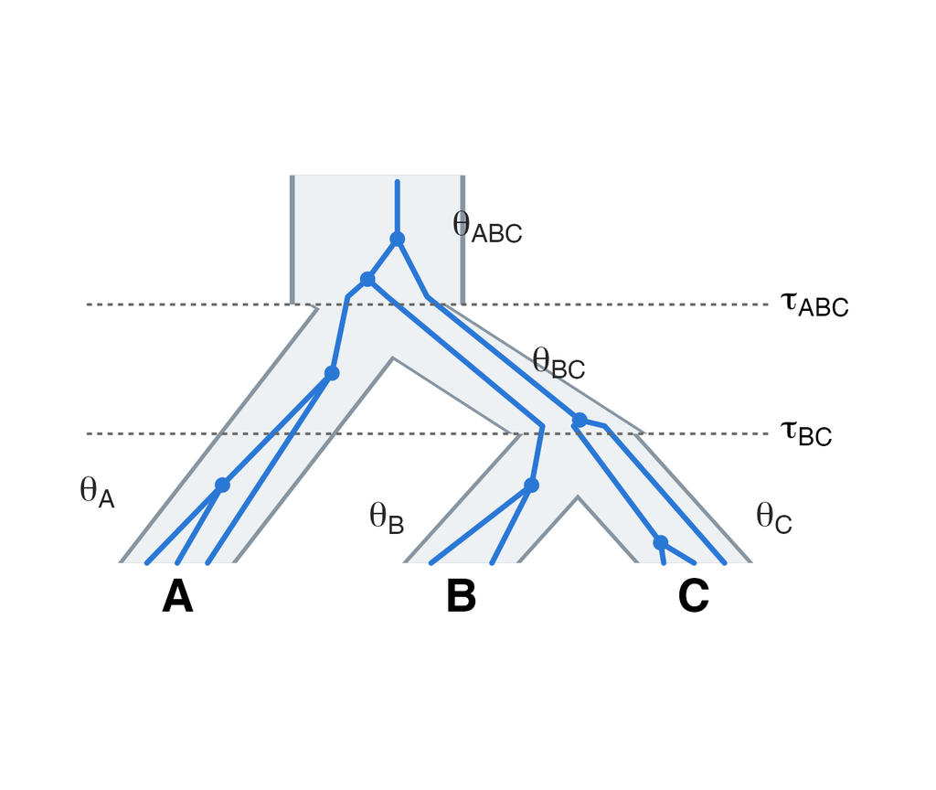

- Lineages coalesce **independently in each population**, at rate $2/\theta$ per pair.
- Each population’s process is **censored** at its divergence time; survivors enter the parent, where the clock restarts.
- Time is in **expected mutations per site**.
- Two kinds of parameter: divergence times $\tau$, and population sizes $\theta = 4N\mu$ (Rannala and Yang 2003).
- Any number of individuals per species.

## The gene-tree density, one population at a time

For a population of duration $\tau$ that $m$ lineages enter and $n$ leave (Rannala and Yang 2003, eq. 8):

$$\underbrace{\prod_{j=n+1}^{m}\frac{2}{\theta}\exp\left\{-\frac{j(j-1)}{\theta}\,t_j\right\}}_{\text{each coalescence, and which pair}}
\;\times\;
\underbrace{\exp\left\{-\frac{n(n-1)}{\theta}\Big[\tau - \textstyle\sum_j t_j\Big]\right\}}_{\text{no more coalescences before } \tau}$$

- $t_j$ = waiting time while $j$ lineages remain; the total rate is $\binom{j}{2}\cdot\frac{2}{\theta} = \frac{j(j-1)}{\theta}$.
- This is the popgen result $f(T_j)=\binom{j}{2}e^{-\binom{j}{2}T_j}$ with time rescaled, $t = T\theta/2$, then censored at $\tau$.
- $f(G,t\mid\Theta)$ for the whole locus = the **product over populations**.

## The MSC likelihood

$$\ell(\Theta) = \sum_{i=1}^{L}\log f(X_i\mid\Theta)
= \sum_{i=1}^{L}\log\left\{\sum_{G_i}\int_{t_i}
\bbox[#DCEBFA,3px]{f(G_i,t_i\mid\Theta)}\;
\bbox[#DDF3EA,3px]{f(X_i\mid G_i,t_i)}\,dt_i\right\}$$

# Estimating species trees

## Full-likelihood methods

$$\ell(\Theta) = \sum_{i=1}^{L}\log\left\{\sum_{G_i}\int_{t_i}
\bbox[#DCEBFA,3px]{f(G_i,t_i\mid\Theta)}\;
\bbox[#DDF3EA,3px]{f(X_i\mid G_i,t_i)}\,dt_i\right\}$$

- You supply only the **sequences**; MCMC jointly samples the **gene trees** and the **species tree** — so this is only practical with Bayesian methods.
- Can be very slow, or impossible, for many loci and moderate numbers of tips.
- Software: **StarBEAST2** (Ogilvie, Bouckaert, and Drummond 2017), **BPP** (Rannala and Yang 2017; Flouri et al. 2018).

## Summary methods: ASTRAL

$$\ell(\Theta) \approx \sum_{i=1}^{L}\log\left\{\sum_{G_i}\int_{t_i}
\bbox[#DCEBFA,3px]{f(G_i,t_i\mid\Theta)}\;
\cancel{f(X_i\mid G_i,t_i)}\,dt_i\right\}$$

- Estimate each **gene tree** first (e.g. IQ-TREE), then treat it as **known** data.
- ASTRAL finds the species tree sharing the most **quartets** with the gene trees: consistent under the MSC — *if* the gene trees are right (Zhang et al. 2018).

## Summary methods: ASTRAL

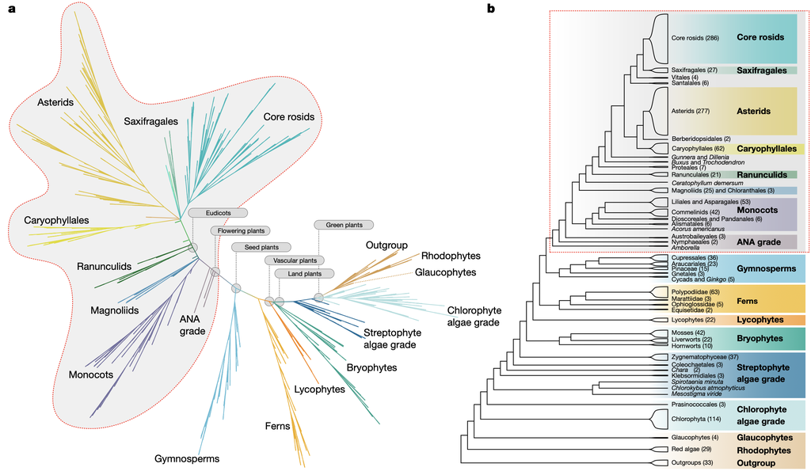

Large species tree estimations with ASTRAL. Fig 2. of One Thousand Plant Transcriptomes Initiative (2019)

## When the gene trees are wrong

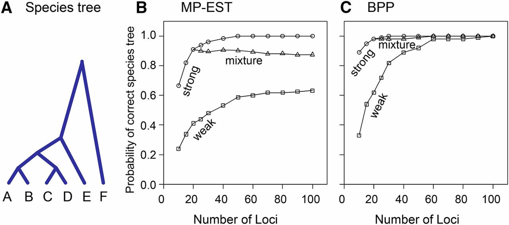

Simulated species trees estimation with summary (MP-EST) and full-likelihood (BPP) methods. From Xu and Yang (2016)

How much error is in empirical data?

- A non-trivial example: In Malpighiales, gene-tree estimation error explains more gene-tree variation (52%) than gene flow (32%) or ILS (15%) (Cai et al. 2021).

# Species delimitation under the MSC

## Single-locus delimitation: barcoding

Before more easily obtainable data, barcoding studies were a common approach for species identification.

- One standard locus that could be easily amplified from anything was sequenced, such as *rbcL* or *matK* for land plants (CBOL Plant Working Group 2009).

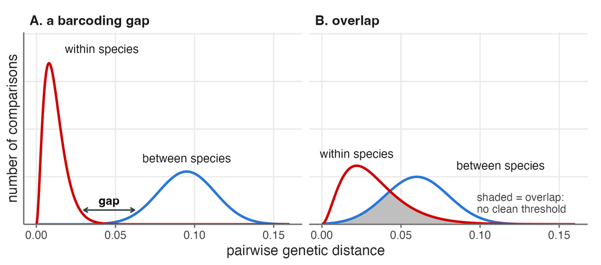

Conceptual illustration of the barcoding gap

## Testing species hypotheses with the MSC

Using the MSC and model selection techniques to accept or reject species hypotheses.

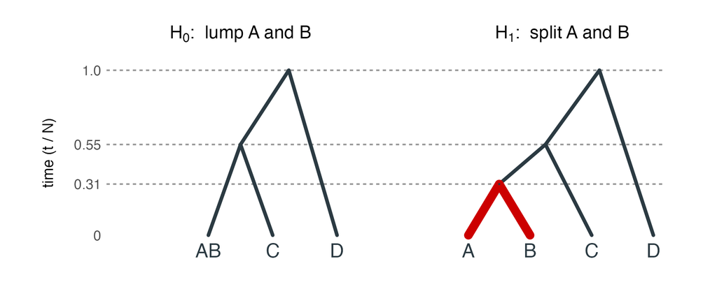

$$\mathrm{LRT} = 2\,(\ln L_{1} - \ln L_{0})$$

## Bayesian approaches: delimiting species on a guide tree

- Each delimitation is a different MSC model; reversible-jump MCMC moves among them (Yang and Rannala 2010).
- Output: the **posterior probability** of each delimitation, and of the number of species.

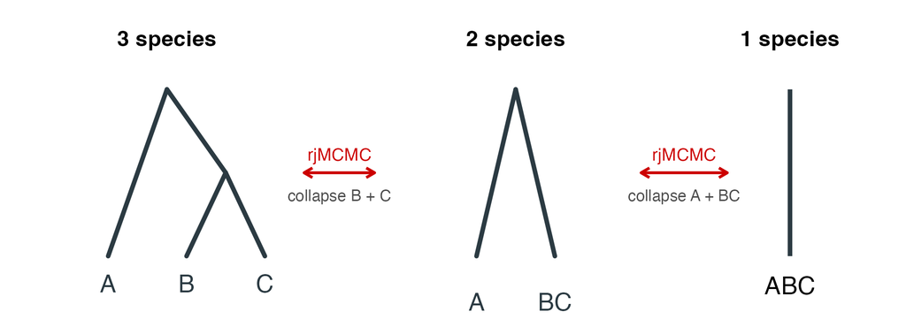

Using reverse jump moves to estimate posterior probabilities for species hypotheses.

## Plant delimitation with the MSC: case studies

| Group | Data | Methods | Outcome |
| --- | --- | --- | --- |
| *Nastanthus*–*Gamocarpha* (Calyceraceae) | 63 individuals, 13 spp. | BPP (A11), BFD, StarBEAST2 | most lineages upheld; *Nastanthus* sunk into *Gamocarpha* (Denham et al. 2019) |
| *Magnolia pacifica* complex | 3 plastid + 3 nuclear loci, 67 individuals | BPP (A10, A11) | five distinct lineages (Ordorica-Velarde et al. 2026) |
| Diploid blueberries (*Vaccinium* sect. *Cyanococcus*) | Hyb-Seq | species trees, gene-flow tests | most morphospecies monophyletic; *V. pallidum* a homoploid hybrid (Crowl et al. 2022) |
| *Pedicularis* sect. *Cyathophora* | up to ~40,000 RAD loci | ML, concordance, D-statistics | two clades; introgression among nearly all taxa (Eaton and Ree 2013) |

Regardless of the input data, the same MSC questions apply.

## Bayes-factor delimitation

$$\mathrm{BF}_{10} = \frac{p(D\mid M_1)}{p(D\mid M_0)},
\qquad
p(D\mid M) = \int \underbrace{p(D\mid\theta, M)}_{\text{likelihood}}\;\underbrace{p(\theta\mid M)}_{\text{prior}}\,d\theta$$

- $p(D\mid M)$ is the **marginal likelihood**: the likelihood averaged over the prior.
- It can’t be read off an MCMC run. It needs a sampling technique across multiple MCMC runs to remove effects of the priors (Xie et al. 2011).
- Feasible for small samples, similar to how it was applied to sub-clades across *Nastanthus*–*Gamocarpha* (Denham et al. 2019).

# Key takeaways

## Summary

# References

Cai, Liming, Zhenxiang Xi, Emily Moriarty Lemmon, et al. 2021. “The Perfect Storm: Gene Tree Estimation Error, Incomplete Lineage Sorting, and Ancient Gene Flow Explain the Most Recalcitrant Ancient Angiosperm Clade, Malpighiales.” *Systematic Biology* 70 (3): 491–507. https://doi.org/10.1093/sysbio/syaa083.

CBOL Plant Working Group. 2009. “A DNA Barcode for Land Plants.” *Proceedings of the National Academy of Sciences* 106 (31): 12794–97. https://doi.org/10.1073/pnas.0905845106.

Crowl, Andrew A., Peter W. Fritsch, George P. Tiley, et al. 2022. “A First Complete Phylogenomic Hypothesis for Diploid Blueberries (Vaccinium Section Cyanococcus).” *American Journal of Botany* 109 (10): 1596–606. https://doi.org/10.1002/ajb2.16065.

Degnan, James H., and Noah A. Rosenberg. 2006. “Discordance of Species Trees with Their Most Likely Gene Trees.” *PLoS Genetics* 2 (5): e68. https://doi.org/10.1371/journal.pgen.0020068.

Denham, Silvia S., Nicolás F. Brignone, Leigh A. Johnson, and Raúl E. Pozner. 2019. “Using Integrative Taxonomy and Multispecies Coalescent Models for Phylogeny Reconstruction and Species Delimitation Within the ‘Nastanthus–Gamocarpha’ Clade (Calyceraceae).” *Molecular Phylogenetics and Evolution* 130: 211–26. https://doi.org/10.1016/j.ympev.2018.10.015.

Durand, Eric Y., Nick Patterson, David Reich, and Montgomery Slatkin. 2011. “Testing for Ancient Admixture Between Closely Related Populations.” *Molecular Biology and Evolution* 28 (8): 2239–52. https://doi.org/10.1093/molbev/msr048.

Eaton, Deren A. R., and Richard H. Ree. 2013. “Inferring Phylogeny and Introgression Using RADseq Data: An Example from Flowering Plants (Pedicularis: Orobanchaceae).” *Systematic Biology* 62 (5): 689–706. https://doi.org/10.1093/sysbio/syt032.

Flouri, Tomáš, Xiyun Jiao, Bruce Rannala, and Ziheng Yang. 2018. “Species Tree Inference with BPP Using Genomic Sequences and the Multispecies Coalescent.” *Molecular Biology and Evolution* 35 (10): 2585–93. https://doi.org/10.1093/molbev/msy147.

Green, Richard E., Johannes Krause, Adrian W. Briggs, et al. 2010. “A Draft Sequence of the Neandertal Genome.” *Science* 328 (5979): 710–22. https://doi.org/10.1126/science.1188021.

Hudson, Richard R. 1983. “Testing the Constant-Rate Neutral Allele Model with Protein Sequence Data.” *Evolution*, 203–17.

Jiao, Yuannian, Norman J. Wickett, Saravanaraj Ayyampalayam, et al. 2011. “Ancestral Polyploidy in Seed Plants and Angiosperms.” *Nature* 473 (7345): 97–100. https://doi.org/10.1038/nature09916.

Lee-Yaw, Julie A., Christopher J. Grassa, Simon Joly, Rose L. Andrew, and Loren H. Rieseberg. 2019. “An Evaluation of Alternative Explanations for Widespread Cytonuclear Discordance in Annual Sunflowers (Helianthus).” *New Phytologist* 221 (1): 515–26. https://doi.org/10.1111/nph.15386.

Martin, Simon H., John W. Davey, and Chris D. Jiggins. 2015. “Evaluating the Use of ABBA–BABA Statistics to Locate Introgressed Loci.” *Molecular Biology and Evolution* 32 (1): 244–57. https://doi.org/10.1093/molbev/msu269.

Ogilvie, Huw A., Remco R. Bouckaert, and Alexei J. Drummond. 2017. “StarBEAST2 Brings Faster Species Tree Inference and Accurate Estimates of Substitution Rates.” *Molecular Biology and Evolution* 34 (8): 2101–14. https://doi.org/10.1093/molbev/msx126.

One Thousand Plant Transcriptomes Initiative. 2019. “One Thousand Plant Transcriptomes and the Phylogenomics of Green Plants.” *Nature* 574 (7780): 679–85. https://doi.org/10.1038/s41586-019-1693-2.

Ordorica-Velarde, Alejandro, Brenda Díaz-Cárdenas, Miguel Angel Muñiz-Castro, et al. 2026. “Resolving the Magnolia pacifica Complex (Magnoliaceae): A Coalescent-Based Approach Reveals Five Distinct Evolutionary Lineages.” *Plant Ecology and Evolution* 159 (2): 375–95. https://doi.org/10.5091/plecevo.178054.

Patterson, Nick, Priya Moorjani, Yontao Luo, et al. 2012. “Ancient Admixture in Human History.” *Genetics* 192 (3): 1065–93. https://doi.org/10.1534/genetics.112.145037.

Pease, James B., David C. Haak, Matthew W. Hahn, and Leonie C. Moyle. 2016. “Phylogenomics Reveals Three Sources of Adaptive Variation During a Rapid Radiation.” *PLOS Biology* 14 (2): e1002379. https://doi.org/10.1371/journal.pbio.1002379.

Rannala, Bruce, and Ziheng Yang. 2003. “Bayes Estimation of Species Divergence Times and Ancestral Population Sizes Using DNA Sequences from Multiple Loci.” *Genetics* 164 (4): 1645–56. https://doi.org/10.1093/genetics/164.4.1645.

———. 2017. “Efficient Bayesian Species Tree Inference Under the Multispecies Coalescent.” *Systematic Biology* 66 (5): 823–42. https://doi.org/10.1093/sysbio/syw119.

Rieseberg, Loren H., Olivier Raymond, David M. Rosenthal, et al. 2003. “Major Ecological Transitions in Wild Sunflowers Facilitated by Hybridization.” *Science* 301 (5637): 1211–16. https://doi.org/10.1126/science.1086949.

Tiley, George P, Jelmer W Poelstra, Mario Dos Reis, Ziheng Yang, and Anne D Yoder. 2020. “Molecular Clocks Without Rocks: New Solutions for Old Problems.” *Trends in Genetics* 36 (11): 845–56.

Xie, Wangang, Paul O. Lewis, Yu Fan, Lynn Kuo, and Ming-Hui Chen. 2011. “Improving Marginal Likelihood Estimation for Bayesian Phylogenetic Model Selection.” *Systematic Biology* 60 (2): 150–60. https://doi.org/10.1093/sysbio/syq085.

Xu, Bo, and Ziheng Yang. 2016. “Challenges in Species Tree Estimation Under the Multispecies Coalescent Model.” *Genetics* 204 (4): 1353–68. https://doi.org/10.1534/genetics.116.190173.

Yang, Ziheng, and Bruce Rannala. 2010. “Bayesian Species Delimitation Using Multilocus Sequence Data.” *Proceedings of the National Academy of Sciences* 107 (20): 9264–69. https://doi.org/10.1073/pnas.0913022107.

Zhang, Chao, Maryam Rabiee, Erfan Sayyari, and Siavash Mirarab. 2018. “ASTRAL-III: Polynomial Time Species Tree Reconstruction from Partially Resolved Gene Trees.” *BMC Bioinformatics* 19 (S6): 153. https://doi.org/10.1186/s12859-018-2129-y.